# ‘graphicsutils’ in a nutshell

Kevin Cazelles

Abstract

The package graphicsutils is a set of miscellaneous functions to be used with the graphics library.

# Introduction

The “graphicsutils” package proposes a set of functions that ease the use of the `graphics` package. As this package is simply a set of function I decide to design the vignette as a cook book exemplifying the functions implemented.

# Empty your plot plot0()

It’s often useful to empty a plot. The plot0 function makes it very easy to do so. Moreover the argument `fill` color the plot region (it is equivalent to calling the `plotAreaColor()`).

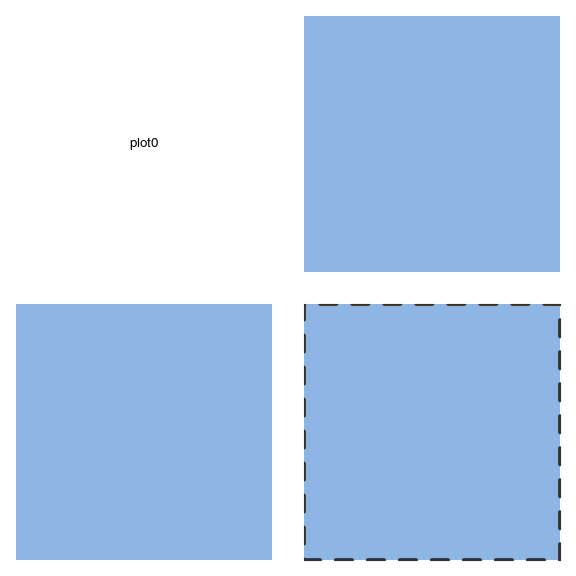

plot0() and plotAreaColor()

```r
par(mar=c(1,1,1,1), mfrow=c(2,2))
#
plot0()
text(0, 0, "plot0")
#
plot0(fill="#8eb5e3")
#
plot0()
plotAreaColor(col="#8eb5e3")
#
plot0()
plotAreaColor(col="#8eb5e3", border="grey20", lty=2, lwd=4)
```

# box2()

The `box2()` function allows the user to add any axes around the plot. A not so bad limitation of the `box()` function is does not allowed all the combination of axes. `box2()` proposes a simple way to select the sides to be added on the plot: 1 = bottom; 2 = left; 3 = top; 4 = right.

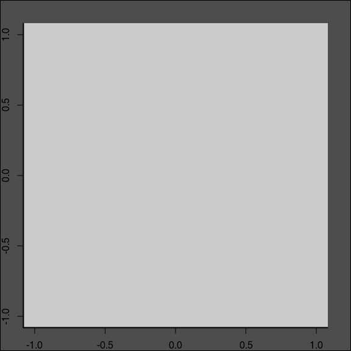

```r
par(mar=rep(2,4))
plot0()
box2(which="figure", lwd=2, fill="grey30")
box2(side=12, lwd=2, fill="grey80")
axis(1)
axis(2)
```

# circles()

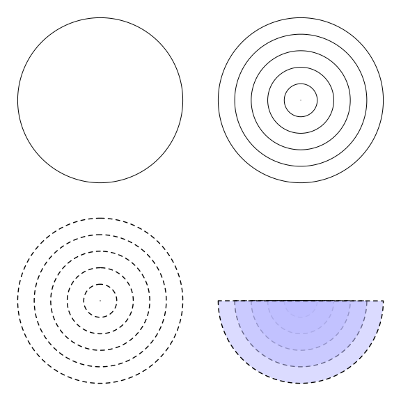

```r
par(mar=c(1,1,1,1), mfrow=c(2,2))
plot0()
circles(0, 0, 1)
plot0()
circles(0, 0, seq(0,1,0.2))
plot0()
circles(0, 0, seq(0,1,0.2), lty=2, lwd=1.4)
plot0()
circles(0, 0 ,seq(0,1,0.2), from=pi, col="#BBBBFF88", lty=2, lwd=1.4)
```

# plotMeans()

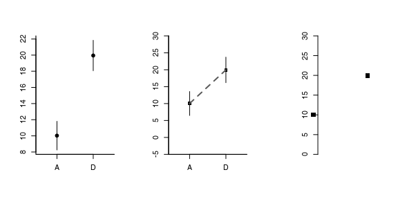

```r
dataset <- data.frame(dat=c(rnorm(50, 10, 2), rnorm(50, 20, 2)) , grp=rep(c('A','D'), each=50))
graphics::par(mfrow=c(1,3))
plotMeans(dat~grp, data=dataset, pch=19)
plotMeans(dat~grp, data=dataset, FUN_err= function(x) sd(x)*2, pch=15,
 ylim=c(-5,30), yaxs='i', connect=TRUE, args_con=list(lwd=2, lty=2, col='grey35'))
ser <- function(x) sd(x)/sqrt(length(x))
plot0(c(0,4), c(0,30))
plotMeans(dat~grp, data=dataset, FUN_err=ser, pch=15,
draw_axis=FALSE, add=TRUE, seqx=c(.5,3.5), mar=c(6,6,1,1), cex=1.4)
graphics::axis(2)
```

# polarPlot()

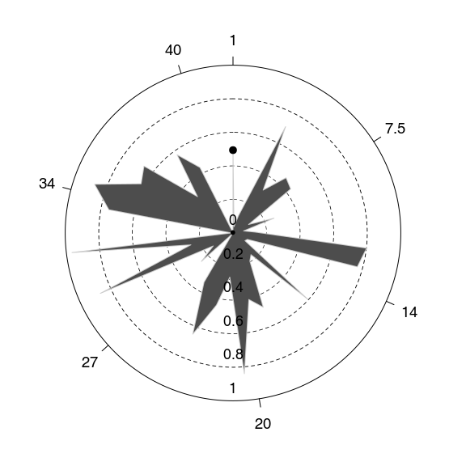

```r
polarPlot(1:40, stats::runif(40), to=1.9*pi, col='grey30', border='grey80')
```

# compassRose

```r
par(mfrow=c(2,2), mar=rep(1,4))
```

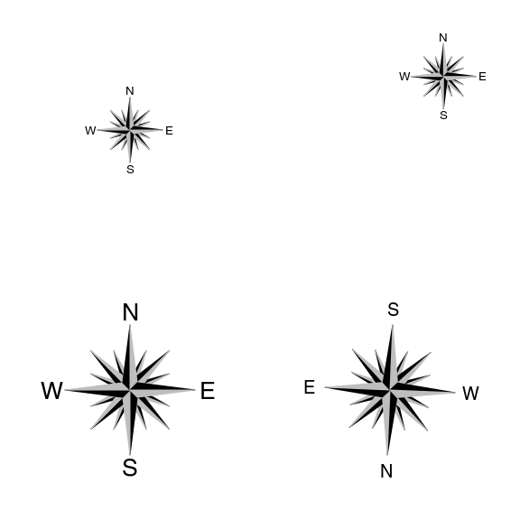

```r
plot0(c(-1,1), asp=1)
compassRose(0, 0)
plot0(c(-1,1), asp=1)
compassRose(0.5, 0.5)
plot0(c(-1,1), asp=1)
compassRose(0, 0, cex.cr=2)
plot0(c(-1,1), asp=1)
compassRose(0, 0, rot=.75*pi, cex.cr=2, cex.let=1.5, offset=-1.25)
```

# envelop

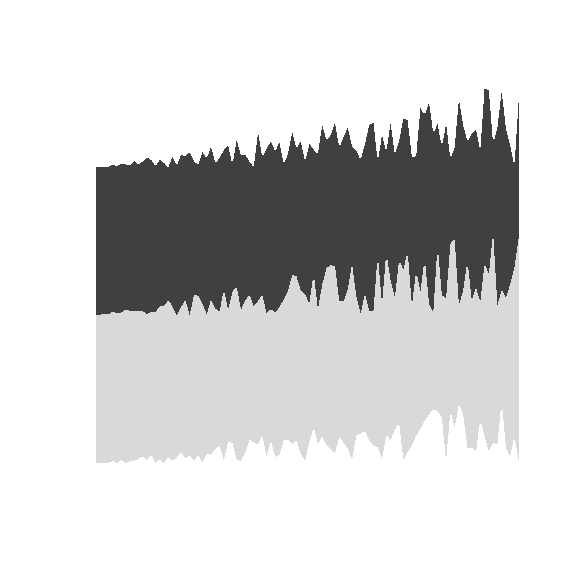

```r
plot0(c(0,10),c(0,10))
sz <- 100
seqx <- seq(0, 10, length.out=sz)
seqy1 <- 0.2*seqx*runif(sz, 0, 1)
seqy2 <- 4+0.25*seqx*runif(sz, 0, 1)
seqy3 <- 8+0.25*seqx*runif(sz, 0, 1)
envelop(seqx, seqy1, seqy2, col='grey85', border=NA)
envelop(seqx, seqy2, seqy3, col='grey25', border=NA)
```

# Add images on plot

## plotImage

[figure not shown]

```r
img <- png::readPNG(system.file('img', 'Rlogo.png', package='png'), native=TRUE)
op <- graphics::par(no.readonly = TRUE)
graphics::par(mfrow=c(2,2), mar=rep(1,4))
for (i in 1:4) plotImage(img)
```

```r
graphics::par(op)
```

## pchImage

[figure not shown]

```r
img<-png::readPNG(system.file('img', 'Rlogo.png', package='png'), native=TRUE)
n<-15
plot0(c(0,1),c(0,1))
pchImage(0.1+0.8*stats::runif(n), 0.1+0.8*stats::runif(n), cex.x=0.2+1.6*stats::runif(n),
obj=img, angle=360*runif(n), col=2)
```

## Creating shades of colors

The `darken()` and `lighten()` functions ease the creation of shades of a given color. For any color palette, use the `showPalette()` to display them!

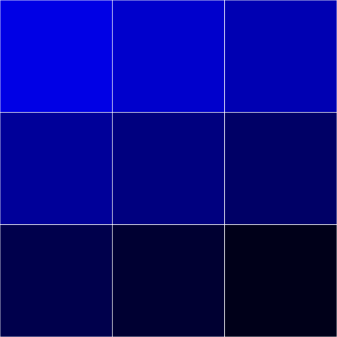

```r
someblue <- darken("blue", 10*1:9)
showPalette(someblue)
```

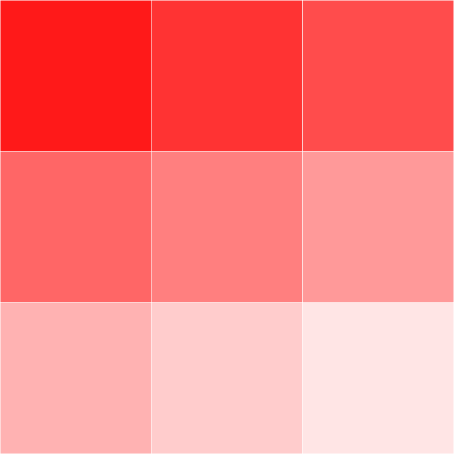

```r
somered <- lighten("red", 10*1:9)
showPalette(somered)
```

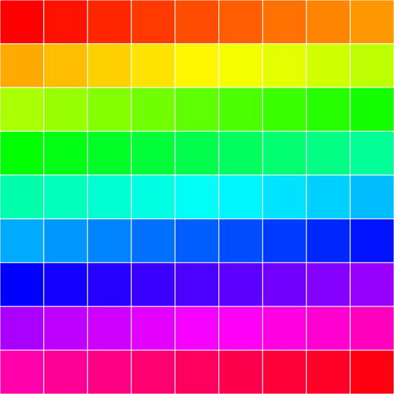

```r
showPalette(rainbow(81))
```

## Encircle points

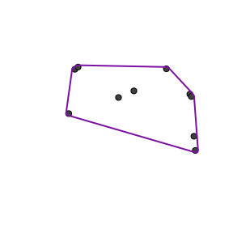

```r
coords <- cbind(runif(10), runif(10))
plot0(coords)
points(coords, bg="grey25", pch=21)
encircle(coords, border="#7b11a1", lwd=2)
```

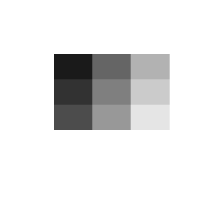

```r
image2(matrix(1:9, 3))
```

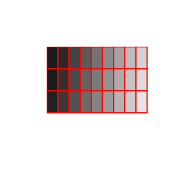

```r
image2(matrix(1:27, 3), from = 2, border = 2, lwd = 2)
```